# Exponential Distributions

Xiangzhu Long

## Introduction

Investigate the exponential distribution in R and compare it with the Central Limit Theorem. Note that you will need to do a thousand simulations.

Illustrate via simulation and associated explanatory text the properties of the distribution of the mean of 40 exponentials. You should

1.Show the sample mean and compare it to the theoretical mean of the distribution.

2.Show how variable the sample is (via variance) and compare it to the theoretical variance of the distribution.

3.Show that the distribution is approximately normal.

## Simulation

```r
# load the packages knitr and ggplot2
library(knitr)
library(ggplot2)
# Set the global options
lambda = 0.2
n = 40  # number of exponential random variables
nsims = 1: 10000  # number of simulated averages
set.seed(901)
means <- data.frame( x=sapply( nsims,
                               function(x) {
                                 mean(rexp(n,lambda) ) } ) )
head(means)
```

```
##          x
## 1 3.981570
## 2 4.148078
## 3 5.381641
## 4 7.407481
## 5 5.728554
## 6 4.603895
```

```r
# Analysis

# Center of the distribution of sample means
mean <- round(mean(means$x), 3)

# Standard deviation of sample means
sd <- round(sd(means$x), 3)

# Expected standard deviation
E <- round((1/lambda)/(sqrt(40)), 3)

# Variance of our simulations
var <- round(var(means$x), 3)

# Expected variance
E2 <- round(E ^ 2, 3)

# Center of the distribution of sample means
hmeans <- round(rowMeans(means), 3)
```

## Result

### Show where the distribution is centered at and compare it to the theoretical center of the distribution.

Answer: The center of the distribution: 5.002, is close to the expected center: λ^−1 = 5, and the variance of sample means is 0.621 where the theoretical variance of the distribution is ( σ^2 )/n=1/(λ^2 * n)=1/(0.04×40) = 0.625.

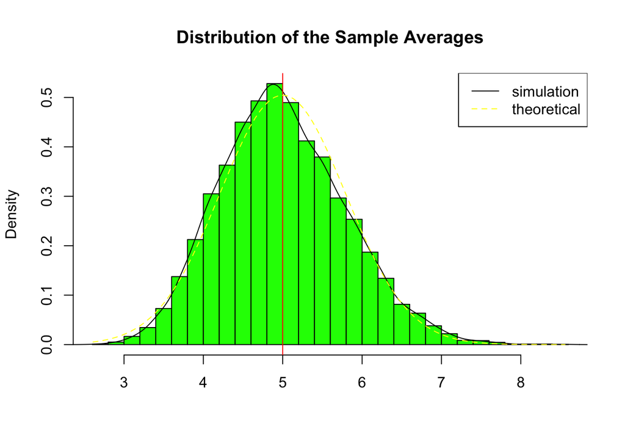

```r
hist(hmeans, col = 'green', breaks = 40,
     prob = TRUE, main = "Distribution of the Sample Averages",
     xlab = "")

# density of the sample averages
lines( density(hmeans) )

# theoretical center of distribution
abline(v = 1/lambda, col = "red")

# theoretical density of the averages of samples
xfit <- seq(min(hmeans), max(hmeans), length = 100)
yfit <- dnorm(xfit, mean = 1/lambda, sd = (1/lambda/sqrt(n)))
lines(xfit, yfit, pch = 19, col = "yellow", lty=2)

legend('topright', c("simulation", "theoretical"),
       lty = c(1,2), col = c("black", "yellow"))
```

### Show how variable it is and compare it to the theoretical variance of the distribution.

Answer: The standard deviation of 0.788 is also close to the expected standard deviation, which is 0.791. Expected standard deviation using CLE.

### Show that the distribution is approximately normal.

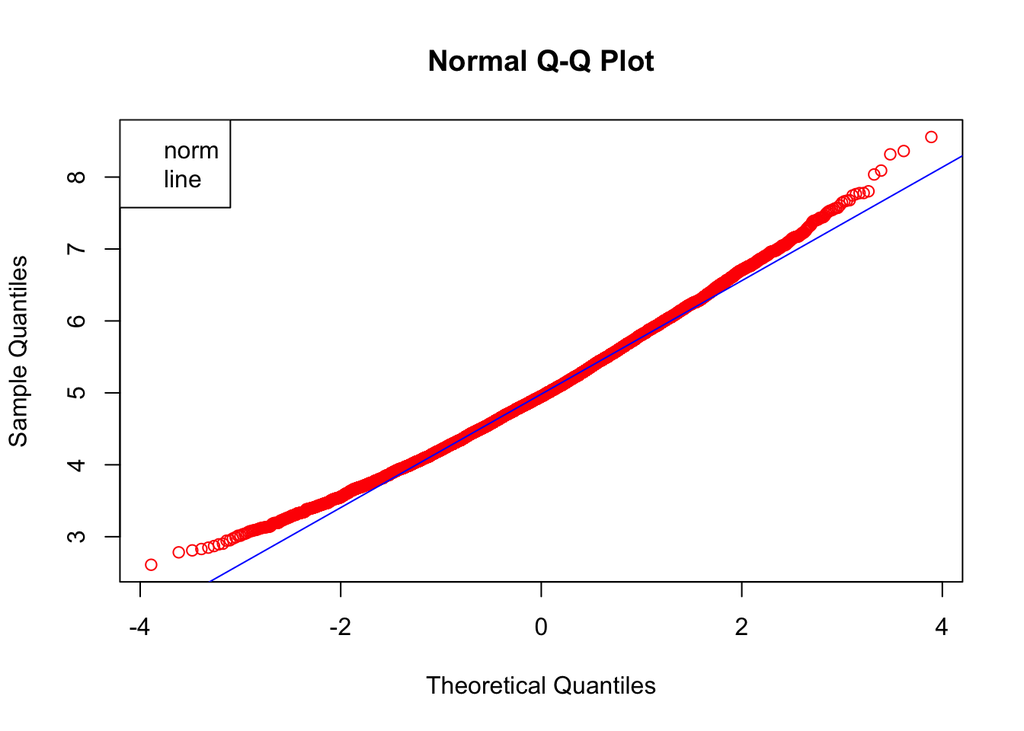

```r
qqnorm(hmeans, col = I('red'))
qqline(hmeans, col = I('blue'))
legend('topleft', c("norm", "line"),
       col = c("red", "blue"))
```